# Lab 3

Nathan Preuss

2020-09-06

# Task 1

WD

```r
getwd()
```

```
## [1] "C:/Users/Nathan/Documents/R_Projects/MATH4753PREU0001/Lab 3"
```

# Task 2

```r
spruce.df = read.csv("SPRUCE.csv")
names(spruce.df)[names(spruce.df) == "ï..BHDiameter"] <- "BHDiameter"
head(spruce.df)
```

```
##   BHDiameter Height
## 1       18.9   20.0
## 2       16.6   18.8
## 3       15.5   16.8
## 4       15.5   16.9
## 5       19.4   20.2
## 6       13.7   16.3
```

# Task 3

Scatter Plot of the data.

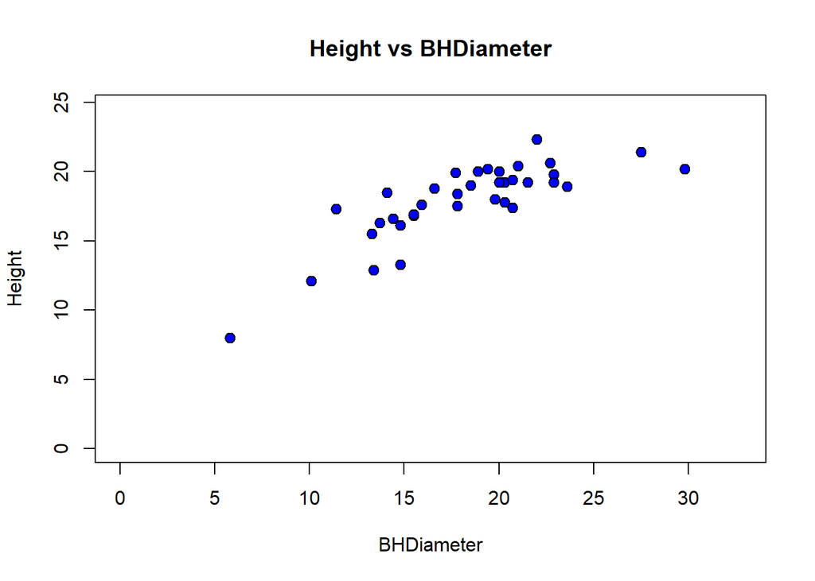

```r
with(spruce.df,  {
plot(Height~BHDiameter,bg="Blue",pch=21, cex=1.2, ylim=c(0,max(Height)*1.1),xlim=c(0,max(BHDiameter)*1.1), xlab="BHDiameter", ylab="Height", main="Height vs BHDiameter")
 }
)
```

There exists a possibility for a straight line relationship.

Loess Plots:

```r
library(s20x)
with(spruce.df,  {
  layout(matrix(1:3,nr=3))
  trendscatter(Height~BHDiameter,f=0.5, data=spruce.df, main="f=0.5")
  trendscatter(Height~BHDiameter,f=0.6, data=spruce.df, main="f=0.6")
  trendscatter(Height~BHDiameter,f=0.7, data=spruce.df, main="f=0.7")
  }
)
```

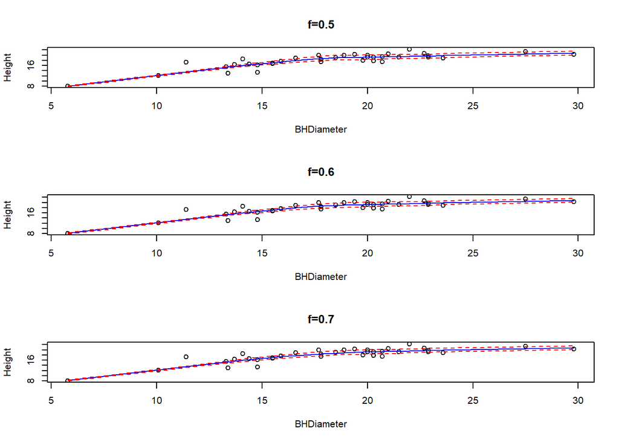

Creating the linear model

```r
spruce.lm=with(spruce.df, lm(Height~BHDiameter))
```

Creating the scatter plot with the abline

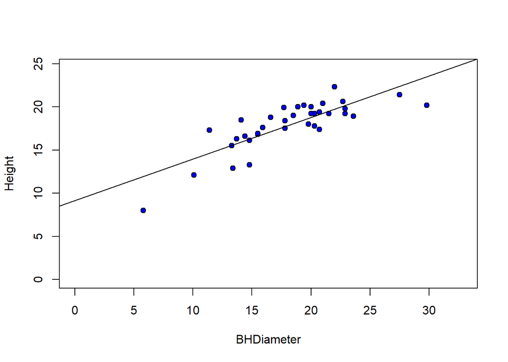

```r
with(spruce.df,
plot(Height~BHDiameter,bg="Blue",pch=21,ylim=c(0,1.1*max(Height)),xlim=c(0,1.1*max(BHDiameter)))
)
abline(spruce.lm)
```

To see if the straight line is appropriate, I would look calculate a fit statistic, or the R-Squared value for the straight line.

```r
summary(spruce.lm)
```

```
##
## Call:
## lm(formula = Height ~ BHDiameter)
##
## Residuals:
##     Min      1Q  Median      3Q     Max
## -3.9394 -0.9763  0.2829  0.9950  2.6644
##
## Coefficients:
##             Estimate Std. Error t value Pr(>|t|)
## (Intercept)  9.14684    1.12131   8.157 1.63e-09 ***
## BHDiameter   0.48147    0.05967   8.069 2.09e-09 ***
## ---
## Signif. codes:  0 '***' 0.001 '**' 0.01 '*' 0.05 '.' 0.1 ' ' 1
##
## Residual standard error: 1.678 on 34 degrees of freedom
## Multiple R-squared:  0.6569, Adjusted R-squared:  0.6468
## F-statistic:  65.1 on 1 and 34 DF,  p-value: 2.089e-09
```

As we can see, the straight line has an R-Squared value of .6569, low, but not too bad. Calculating a fit statistic for loess is impossible, but it does look like the curves fit the data quite nicely.

# Task 4

Making the 4 plots:

```r
layout(matrix(1:4,nr=2,nc=2,byrow=TRUE))

#plot 1
with(spruce.df,
  plot(Height~BHDiameter,bg="Blue",pch=21,ylim=c(0,1.1*max(Height)),xlim=c(0,1.1*max(BHDiameter)))+abline(spruce.lm)
)
```

```
## integer(0)
```

```r
mtext("Scatter Plot",side=3)

# make a linear model
spruce.lm=with(spruce.df, lm(Height~BHDiameter))

#make a new plot
with(spruce.df,
     plot(Height~BHDiameter, bg="Blue",pch=21,ylim=c(0,1.1*max(Height)),xlim=c(0,1.1*max(BHDiameter)))
)
abline(spruce.lm)

#make yhat the estimates of E[Height | BHDiameter]
yhat=with(spruce.df,predict(spruce.lm,data.frame(BHDiameter)))
#OR you could use -- (yhat values the predicted values for all the BHDiameter values )
yhat=fitted(spruce.lm)

# Draw in segments making the residuals (regression deviations)
with(spruce.df,{
segments(BHDiameter,Height,BHDiameter,yhat)
})
abline(spruce.lm)

#residual sum of squares
RSS=with(spruce.df,sum((Height-yhat)^2))

RSS
```

```
## [1] 95.70281
```

```r
mtext("RSS Plot",side=3)
#make a new plot
with(spruce.df,
plot(Height~BHDiameter, bg="Blue",pch=21,ylim=c(0,1.1*max(Height)),xlim=c(0,1.1*max(BHDiameter)))
)

#make nieve model
with(spruce.df, abline(h=mean(Height)))
abline(spruce.lm)
mtext("MSS Plot",side=3)

#make the explained deviations (explained by the model)
with(spruce.df, segments(BHDiameter,mean(Height),BHDiameter,yhat,col="Red"))
MSS=with(spruce.df,sum((yhat-mean(Height))^2))
MSS
```

```
## [1] 183.2447
```

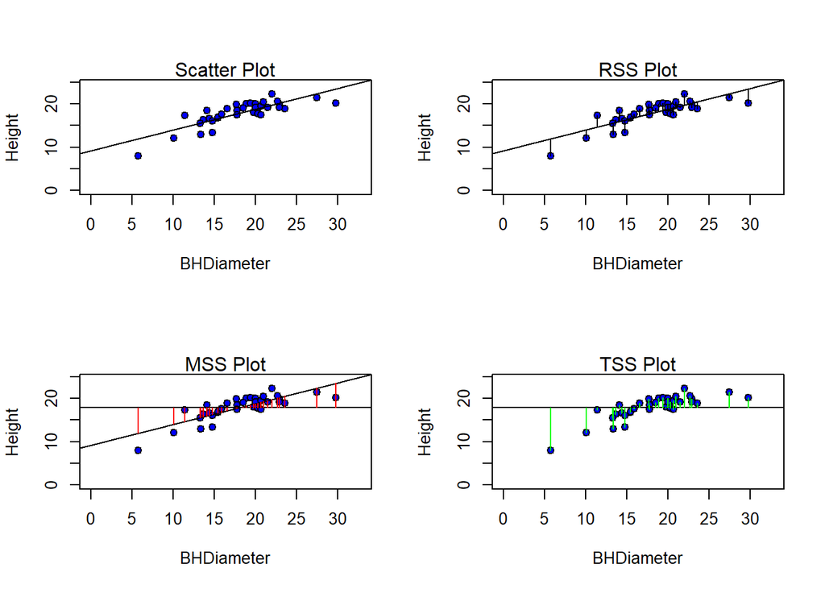

```r
# Total  error
#make a new plot

with(spruce.df,
plot(Height~BHDiameter, bg="Blue",pch=21,ylim=c(0,1.1*max(Height)),xlim=c(0,1.1*max(BHDiameter)))
)
with(spruce.df,abline(h=mean(Height)))
with(spruce.df, segments(BHDiameter,Height,BHDiameter,mean(Height),col="Green"))
mtext("TSS Plot",side=3)
```

```r
TSS=with(spruce.df,sum((Height-mean(Height))^2))
TSS
```

```
## [1] 278.9475
```

Calculating TSS, MSS, and RSS

```r
TSS
```

```
## [1] 278.9475
```

```r
MSS
```

```
## [1] 183.2447
```

```r
RSS
```

```
## [1] 95.70281
```

TSS= 278.9475, MSS = 183.2447, RSS = 95.7028

$$\frac{MSS}{TSS}= 0.6569$$
This is the measure of fitness for the best fit line, or the R-Squared value. On a scale of 0 to 1, the higher the R-Squared value, the more the data points lie in a straight line.

$$TSS=MSS+RSS$$

```r
MSS+RSS
```

```
## [1] 278.9475
```

```r
TSS
```

```
## [1] 278.9475
```

It does indeed.

# Task 5

Summary of spruce.lm

```r
summary(spruce.lm)
```

```
##
## Call:
## lm(formula = Height ~ BHDiameter)
##
## Residuals:
##     Min      1Q  Median      3Q     Max
## -3.9394 -0.9763  0.2829  0.9950  2.6644
##
## Coefficients:
##             Estimate Std. Error t value Pr(>|t|)
## (Intercept)  9.14684    1.12131   8.157 1.63e-09 ***
## BHDiameter   0.48147    0.05967   8.069 2.09e-09 ***
## ---
## Signif. codes:  0 '***' 0.001 '**' 0.01 '*' 0.05 '.' 0.1 ' ' 1
##
## Residual standard error: 1.678 on 34 degrees of freedom
## Multiple R-squared:  0.6569, Adjusted R-squared:  0.6468
## F-statistic:  65.1 on 1 and 34 DF,  p-value: 2.089e-09
```

```r
coef(spruce.lm)
```

```
## (Intercept)  BHDiameter
##   9.1468390   0.4814743
```

```r
anova(spruce.lm)
```

```
## Analysis of Variance Table
##
## Response: Height
##            Df  Sum Sq Mean Sq F value    Pr(>F)
## BHDiameter  1 183.245 183.245  65.101 2.089e-09 ***
## Residuals  34  95.703   2.815
## ---
## Signif. codes:  0 '***' 0.001 '**' 0.01 '*' 0.05 '.' 0.1 ' ' 1
```

The value of the slope is .48147. The value of the intercept is 9.14684
$$Height = 0.48147\times BHDiameter + 9.14684$$

The predicted values:

```r
predict(spruce.lm, data.frame(BHDiameter=c(15,18,20)))
```

```
##        1        2        3
## 16.36895 17.81338 18.77632
```

We would expect the tree to have a height of 16.369 given a diameter of 15, a height of 17.813 given a diameter of 18, and a height of 18.776 given a diameter of 20.

# Task 6

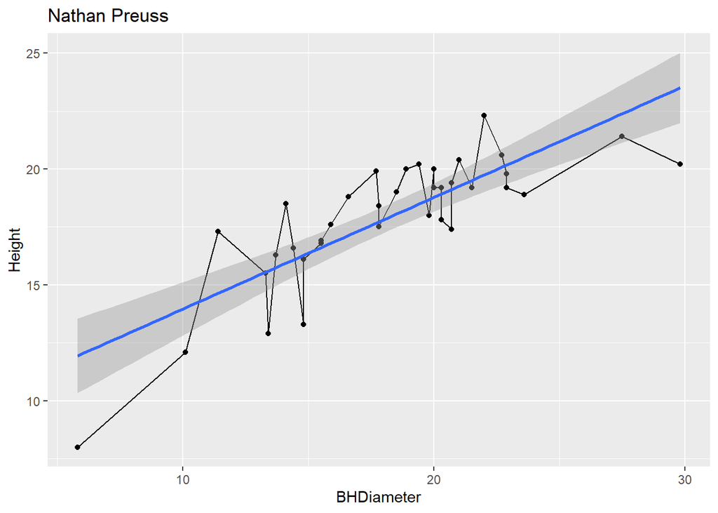

```r
library(ggplot2)
z<-ggplot(spruce.df, aes(x=BHDiameter, y=Height)) + geom_point() + geom_line() + ggtitle("Nathan Preuss") + geom_smooth(method='lm', formula= y~x)
z
```

# Task 7

Shiny App Images

[figure not shown]

[figure not shown]

[figure not shown]